# Using Models 2

Johanna Ravenhurst

2022-12-06

I didn’t work with other students.

```r
#Setup
require(here)
require(palmerpenguins)
```

# Walkthrough code (not included in final output)

#T-tests

#2-sample t-test

#Graphical Data Exploration

#Numerical Exploration - test for normality

#Fit a linear model

#2-way ANOVA with species and sex

# *Model 2 Assignment Questions*

# *Q1-3 Interpreting Boxplots*

*Q1* **Re-create the conditional boxplot of penguin body mass conditioned on sex and species. Include your boxplot as a figure in your report.**

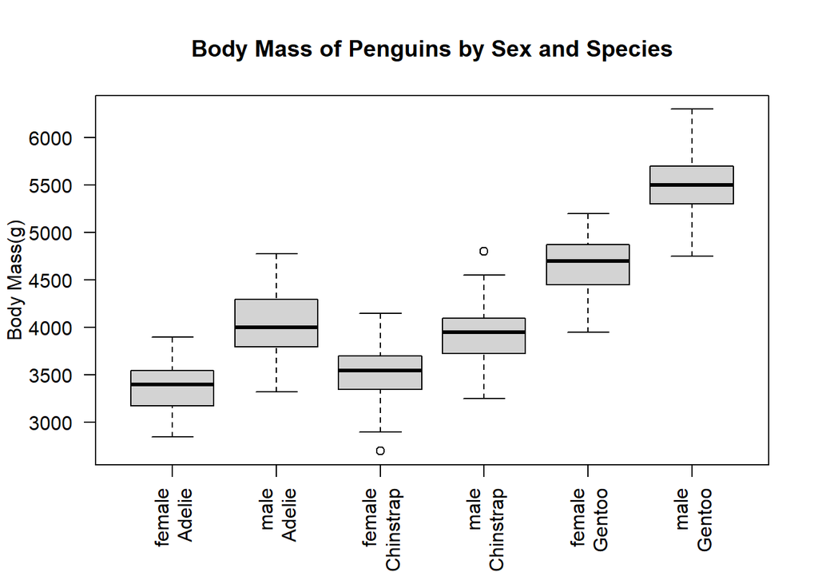

```r
 boxplot(
    body_mass_g ~ sex:species, data = penguins,
    main = "Body Mass of Penguins by Sex and Species",
    ylab = "Body Mass(g)",
    xlab = NULL,
    names = c("female\nAdelie","male\nAdelie", "female\nChinstrap", "male\nChinstrap", "female\nGentoo", "male\nGentoo"),
    las=2)
```

*Q2* **Based on the boxplots, do you think male penguins are significantly heavier than female penguins of the same species? Explain your reasoning, and be sure to explain why you think any observed differences are significant or not.**

Yes, I think male penguins are significantly heavier than female penguins of the same species based on the boxplots. The conditional boxplot shows that the mean body mass of male penguins is clearly much higher than the mean body mass of female penguins for each species. Even when including the variability around the mean, the main box for each distribution appears to be covering a different range of body mass values for male vs. female penguins for each species.

*Q3* **Do you think adding sex to a model that already includes species will improve the model fit?**

Yes, I think adding sex to a model that already includes species will improve the model fit and describe more of the variation in the data than just including species in the model. The boxplots show that there is a difference in body mass based on sex of the penguin, so I think including this variable in the model should help to explain some of the variation in body mass of penguins.

# *Q4-5 Model Fit 1*

*Q4* **Show the R-code you used to build fit_both.**

```r
fit_both = lm(body_mass_g ~ sex * species, data = penguins)
summary(fit_both)
```

```
##
## Call:
## lm(formula = body_mass_g ~ sex * species, data = penguins)
##
## Residuals:
##     Min      1Q  Median      3Q     Max
## -827.21 -213.97   11.03  206.51  861.03
##
## Coefficients:
##                          Estimate Std. Error t value Pr(>|t|)
## (Intercept)               3368.84      36.21  93.030  < 2e-16 ***
## sexmale                    674.66      51.21  13.174  < 2e-16 ***
## speciesChinstrap           158.37      64.24   2.465  0.01420 *
## speciesGentoo             1310.91      54.42  24.088  < 2e-16 ***
## sexmale:speciesChinstrap  -262.89      90.85  -2.894  0.00406 **
## sexmale:speciesGentoo      130.44      76.44   1.706  0.08886 .
## ---
## Signif. codes:  0 '***' 0.001 '**' 0.01 '*' 0.05 '.' 0.1 ' ' 1
##
## Residual standard error: 309.4 on 327 degrees of freedom
##   (11 observations deleted due to missingness)
## Multiple R-squared:  0.8546, Adjusted R-squared:  0.8524
## F-statistic: 384.3 on 5 and 327 DF,  p-value: < 2.2e-16
```

```r
#Base case = Female Adelie penguins
#Significant p-value for everything except male Gentoo

#Conduct an ANOVA
anova(fit_both)
```

```
## Analysis of Variance Table
##
## Response: body_mass_g
##              Df    Sum Sq  Mean Sq F value    Pr(>F)
## sex           1  38878897 38878897 406.145 < 2.2e-16 ***
## species       2 143401584 71700792 749.016 < 2.2e-16 ***
## sex:species   2   1676557   838278   8.757 0.0001973 ***
## Residuals   327  31302628    95727
## ---
## Signif. codes:  0 '***' 0.001 '**' 0.01 '*' 0.05 '.' 0.1 ' ' 1
```

*Q5* **What is the base case for the two-way model that includes sex and species?**

Base case = Female Adelie penguins

# *Q6-8 Model Coefficients*

*Q6* **What are the names of the two coefficients (from the first column of the coefficient table) that you need to calculate the average mass of female Chinstrap penguins?** (Intercept) speciesChinstrap

*Q7* **What is the predicted average mass of female Chinstrap penguins in the interactive model?** 3368.84 + 158.37 = 3,527.21 g

*Q8* **What is the observed average mass of female Chinstrap penguins, calculated from the penguins data?** Observed average mass of female Chinstrap penguins = 3,527.206 g

```r
#Shortcut for calculating mean body masses using aggregate
aggregate(body_mass_g ~ species + sex, data = penguins, FUN = mean)
```

```
##     species    sex body_mass_g
## 1    Adelie female    3368.836
## 2 Chinstrap female    3527.206
## 3    Gentoo female    4679.741
## 4    Adelie   male    4043.493
## 5 Chinstrap   male    3938.971
## 6    Gentoo   male    5484.836
```